# Chapter D1 フィッティングと接続：ボルト接合およびリベット接合

## D1.1 はじめに

理想的な飛行体の構造は、単一の製造工程からなる、同一材料でできた一つの完全なユニットである。しかし、残念ながら現代の材料の種類とその加工方法により、合成構造（コンポジット構造）をとらざるを得ない。さらに、修理、メンテナンス、収納などの一般的な要求事項から、いくつかの主要なユニットで構成され、それらが主フィッティング（主要取付金具）や接続部によって他のユニットに保持される構造が必要となる。また、各ユニット内には、フィッティング、ボルト、リベット、溶接などを伴う多くの一次および二次接続が含まれている。主要なフィッティングは、航空宇宙構造の他のどの部分よりも単位体積あたりの重量とコストが大きくなることは間違いなく、したがって、フィッティングや継手の設計は航空宇宙構造設計において重要な役割を果たしている。

## D1.2 フィッティング設計における経済性

構造の経済性の観点から、構造設計者は飛行体の初期レイアウトにおいて、フィッティング、特に大きな荷重を伝達するユニット同士を接続するフィッティングの使用数を最小限に抑えるよう努めるべきである。例えば、主翼構造において主桁フランジをスプライス（継手結合）したり、飛行機の中心線付近にフィッティングを配置したりすることは、部材のサイズや荷重がかなり小さくなる翼端寄りにスプライスやフィッティングを配置するよりもはるかにコストがかかる。翼桁や胴体のロンジロンのような重量部材の方向変更は、重いフィッティングが必要になるため避けること。連続梁に継手が必要な場合は、継手を経由して伝達される曲げモーメントを小さく抑えるために、変曲点付近に配置すること。端部フィッティングを持つ柱（コラム）の設計では、梁に偏心荷重が生じるのを避け、一方でフィッティングを利用して柱の端部固定度を高めることで、梁の重量を削減し、フィッティング追加による重量増加を相殺するようにすること。

製造の経済性のために、構造設計者は工場の加工プロセスや作業工程について十分な知識を持っている必要がある。フィッティングの製作および組立コストは、フィッティングのタイプ、形状、および要求される公差によって大きく異なる。主要なフィッティング配置の不適切なレイアウトは、工場の製作や組立のために非常に高価な工具や治具を必要とする場合がある。

また、フィッティングは検査のコストを大幅に増加させ、製作上の欠陥や材料の不具合による高価なフィッティングの不合格（却下）もしばしば発生するため、これが単位コストを大幅に押し上げる要因となる。

## D1.3 フィッティング設計荷重。最小安全余裕（Margin of Safety）

他の章で議論されているように、制限荷重（limit loads）は、飛行体がその寿命期間中に遭遇する可能性のある最大荷重であり、要求される地上および飛行運用を行う際にかかるものである。構造は、使用されている材料の降伏応力を超えることなく、制限荷重を支持できなければならない。終局荷重（Ultimate loads）または設計荷重は、制限荷重に安全率（通常、航空機では1.5、ミサイルではそれ以下）を乗じたものである。構造は、終局荷重または設計荷重を破損することなく支持できる十分な強度を持たなければならない。

通常の飛行体構造は、さまざまなタイプの接続部によって結合された多くの部品で構成されている。一般に、これらの接続部の設計には、追加の一括安全率（blanket factor of safety）が必要とされる。この一括安全率は通常1.15から1.20である。ほとんどの接続部やフィッティングの応力解析は、複合応力、応力集中、ボルト穴の締め付け状態などの要因により、主要な構造部材よりも複雑である。したがって、接続される部材の強度設計と同程度の強度信頼性を接続部に持たせるために、追加の安全率が必要となる。

## D1.4 特別または高めの安全率

すべてのタイプのフィッティングや荷重条件に対して、一律の一括安全率を適用することは合理的ではない。継手に荷重が加わる方法は、例えば着陸装置の継手やフィッティングのように、動的荷重や衝撃荷重を伴うことが多い。シングルピン接続では、隣接する部品間で回転や運動が発生することが多く、運用中に材料の摩耗が早まる原因となる。繰り返し荷重はしばしば疲労問題を引き起こす。航空機やミサイルには、破損した場合に確実に機体の損失につながるような、特定の重要なフィッティングが存在する。したがって、軍や民間の航空機関の設計フィッティング要件には、多くの特別な、または高めの安全率が含まれている。これは、特に鋳物を用いた設計において顕著である。

## D1.5 航空機用ボルト

航空機用ボルトは、主に一つの構造部材から別の構造部材へ、比較的大きなせん断荷重または引張荷重を伝達するために使用される。

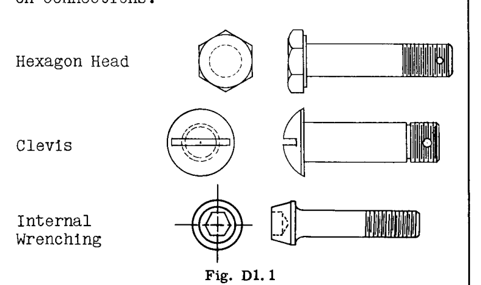

は、一般的に使用されている3種類の標準的な航空機用ボルトを示している。これら以外のタイプも存在するが、接続に関するこの限定された章では紹介しない。

六角頭ボルト（Hexagon Head）は、SAE 2330の3.5%ニッケル鋼で作られた陸海軍標準ボルト（Army-Navy standard bolt）であり、熱処理によって125,000 psiの極限引張強度を持つ。ボルト頭部はボルトの全引張強度を発揮させるのに十分な大きさである。

内部レンチ用ボルト（Internal Wrenching）は高強度鋼製ボルトで、通常160,000〜180,000 psiに熱処理されている。高強度であり、ボルト頭部に必要なスペースが比較的小さいため、特に主要なスプライスフィッティング（継手金具）に適している。

クレビスボルト（Clevis）は、その頭部がボルトの全引張強度を発揮するように設計されていないため、せん断ボルトと呼ばれる。クレビスボルトは、ボルトのせん断荷重によって荷重を伝達するためにボルト群またはボルトのクラスターが必要な場合に一般的に使用される。このようにボルト頭部が小さいため、重量を削減し、ボルト頭部のクリアランスをより大きく確保できる。クレビスボルトは、標準的なAN六角頭ボルトの約半分の引張強度を発揮する。

### ボルト使用における一般ルール

ボルトのねじ部は、支圧（bearing）またはせん断（shear）がかかる場所に配置してはならない。ボルトのシャンク（軸部）の長さは、フィッティング表面の下にねじ山が1山を超えて出ないような長さにすべきであり、これはワッシャーの使用によって調整できる。

主要なフィッティングには、直径が3/8インチ未満のボルトを使用してはならない。スチール製ボルトの場合、直径3/16インチが任意のフィッティングに使用できる最小サイズとすべきである。

相対運動を伴う部品や応力の反転がある部品を接続するボルトは、衝撃荷重を減少させるために厳しい公差（クローズドトレランス）を持つべきである。

相対運動を行う部材を接続するボルトの場合、フィッティングの周囲の部品に潤滑器を組み込むべきである。フィッティング自体に潤滑用の穴を開けてはならない。

ボルトのせん断における強度効率を高め、ボルトの曲げ傾向を減少させるために、ボルトは可能な限りダブルせん断（両面せん断）またはマルチせん断（複数面せん断）で使用すべきである。

## D1.6 航空機用ナット

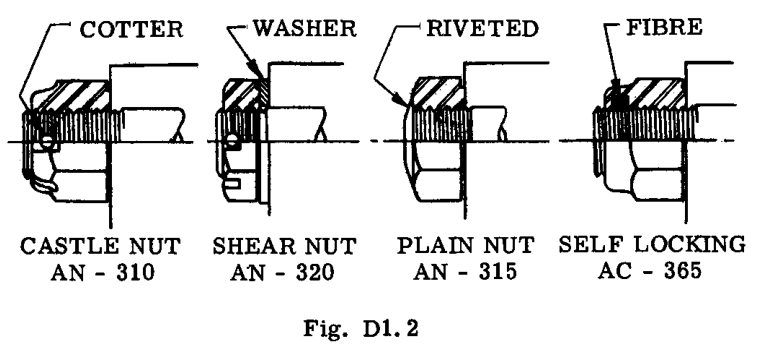

は、4種類の標準的なスチール製航空機用ナットを示している。ナットの材料はボルトの材料よりも延性があるため、ナットを締め付けるとねじ山がたわんでボルトのねじ山に密着する。

キャッスルナット（Castle Nut、溝付きナット）は、おそらく最も一般的な航空機用ナットである。これはボルトの全定格強度を発揮する。ナットにはスロット（溝）が切られており、ナットが回転するのを防止できるようになっている。

シアナット（Shear Nut）は、キャッスルナットの半分の厚さしかなく、したがってボルト引張強度の半分を発揮するだけのねじ山しか持たない。これは、ナットを締め付ける際のトルクを制限するためにスクリュードライバー用スロットを持つクレビスボルトとともに使用される。このナットもコッターピン固定用に溝が切られている。

プレーンナット（Plain Nut）は、現在の設計ではほとんど使用されないが、恒久的な場所に使用され、ボルトの端をナットの上から「ピーニング（叩き潰し）」またはリベット接合することによってロックされる。この作業はボルトの保護コーティングや仕上げを破壊する。

自己保持ナット（Self-Locking Nut、緩み止めナット）は、航空機業界で広く使用されており、市場には多くのタイプが存在する。

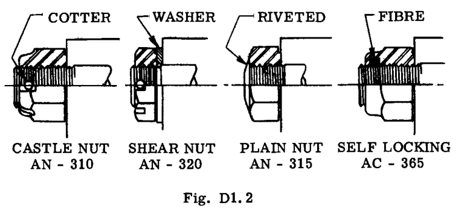

は、ファイバー製インサートを用いた自己保持ナットの一例を示している。ボルトがファイバー製カラーに達すると、カラーの穴がボルトよりも小さく、ねじ山が切られていないため、ファイバーを押し上げる傾向が生じる。これにより、ファイバーリングはボルトに強い下向きの圧力を発生させ、ナットとボルトのねじ山の荷重支持面を自動的に確実な接触状態にする。これにより、ねじ山のすべての遊び（ガタ）が排除され、すべてのボルトとナットのねじ山の間で常に摩擦が発生する。ねじ山に維持されるこの一定の圧力は、振動下でナットが動くのを防ぐ摩擦を提供する。自己保持ナットの使用は、整備士の余分な作業を必要とし、航空機の多くの継手や隅部においてナットへの取り付けが非常に困難な、煩わしいコッターピンを排除するため、組立コストを削減する。別のタイプの自己保持ナットでは、特別に設計されたナットの上部のばね作用によってロック力が提供される。

アルミニウム合金製ナット。アルミニウム合金製ナットは、引張用に設計されたボルトには使用されない。重量削減のために、陸上機でスチール製ボルトにアルミニウム合金製ナットが使用されることがあるが、その場合はボルトがカドミウムめっきされていることが条件となる。ナットが繰り返し取り外されるような場所で使用される場合は、比較的柔らかいねじ山を傷つける危険性があるため、ボルトもナットもアルミニウム合金製にすべきではない。

## D1.7 ボルトのせん断、引張および曲げ強度

Table D1.1 は、室温における AN 標準スチール製ボルトの断面特性、ならびに極限せん断、引張および曲げ強度を示している。

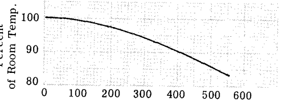

は、ボルトが高温にさらされたときに、Table D1.1 の強度値に適用すべき補正を示している。Table D1.2 は、スチール製内部レンチ用ボルトの引張およびダブルせん断強度を示している。Table D1.2a は、2024 アルミニウム合金製ボルトの極限せん断、引張および曲げ強度を示している。破断係数 $F_b$ の値は、Chapter C3 に示されている方法によって決定された。

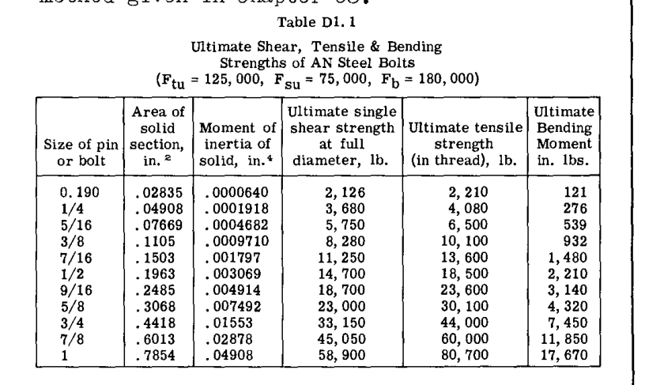

Table D1.1

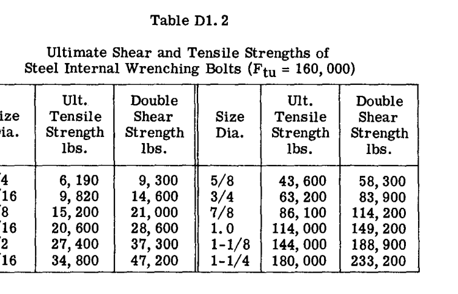

Table D1.2

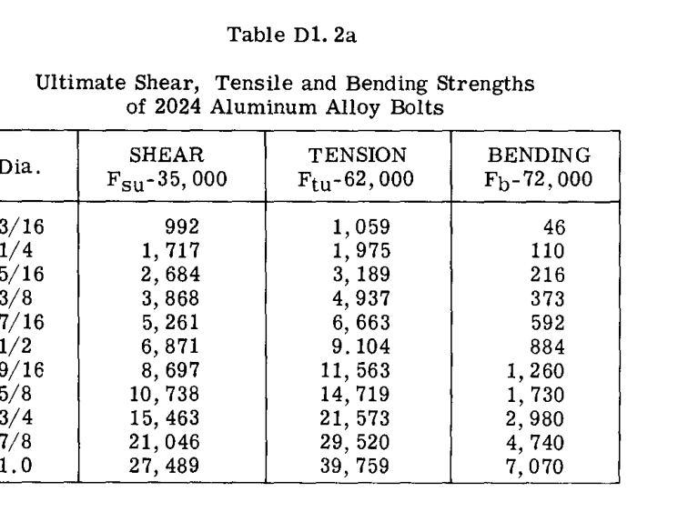

Table D1.2a

## D1.8 複合流（せん断と引張）を受けるボルト

ボルトがせん断荷重と引張荷重の両方を受ける場合、その結果としての強度は以下の相互作用方程式（相関式）によって与えられる（参考文献 1、2）。

$$\frac{x^3}{a^3} + \frac{y^2}{b^2} = 1
\qquad (D1.1)$$

ここで、 * $x$ = せん断荷重 * $y$ = 引張荷重 * $a$ = Table D1.1 から得られる許容せん断荷重 * $b$ = Table D1.1 から得られる許容引張荷重

および

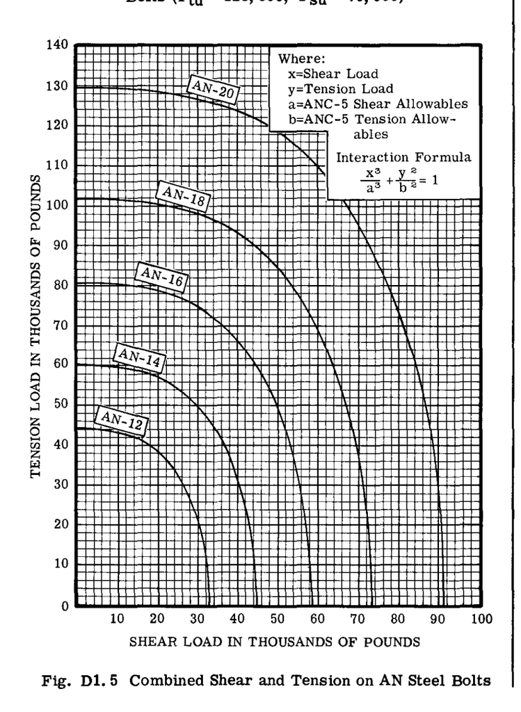

は、さまざまな AN スチール製ボルトサイズに対するこの方程式のプロットである。これらの曲線は、シアナットが使用されている場合には適用できない。これらの曲線は、ナットを手締めした状態での複合荷重試験の結果に基づいている。

## D1.8a ブッシング

応力の反転を受けたり、わずかな回転が生じたりするシングルボルトまたはピン結合フィッティングのラグ（耳部金具）には、ブッシングを設けるのが一般的である。これにより、摩耗が発生した場合に、ラグフィッティングに新しいブッシングを挿入することができる。スチール製のブッシングは、アルミニウム合金製のシングルボルトフィッティングのラグにおいて、ラグの許容支圧応力を高めるために一般的に使用されている。なぜなら、ブッシングによって支圧直径が $1/8$ インチ増加するからである（ブッシングの肉厚は通常 $1/16$ インチである）。もしシングルボルト接続にブッシングを使用しない場合は、ブッシングなしの穴が過度に摩耗した場合に備えて、次のサイズのボルト用に穴をリーマ仕上げできるように、十分な端部距離（エッジディスタンス）を確保しておくべきである。かなりの回転が発生する場合は、プレーンブッシング（すべり軸受）用の潤滑器を設けるか、または含油ブッシングを使用すべきである。

## D1.9 シングルボルトフィッティング

おそらく、2つの部材を結合する最も簡単な方法は、単一のボルトまたはピン接続を使用することである。このような継手は、比較的大きな荷重を伝達することができ、しかも簡単かつ迅速に切り離すことができる。

## D1.10 シングルボルトフィッティングの破損方法と許容破壊荷重

荷重がフィッティングの一方の側から他方の側へ伝達されるとき、フィッティングをいくつかの異なる方法で破損させようとする内部応力が発生する。

### ボルトのせん断による破損

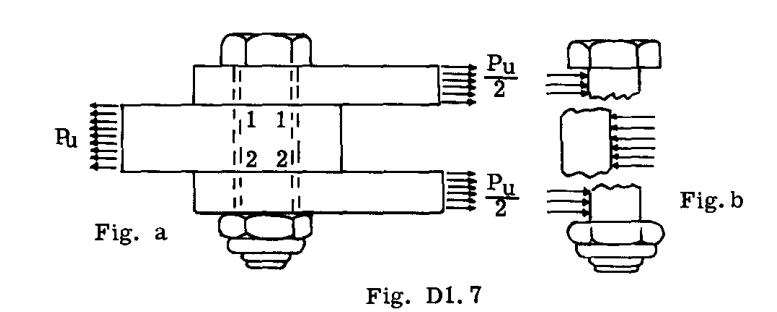

では、ブッシングはプレート間で連続しておらず、3つのプレートのそれぞれが別々のブッシングを持っている。フィッティングに引張力 $P$ が作用すると、セクション (1-1) および (2-2) においてボルトをせん断しようとする。

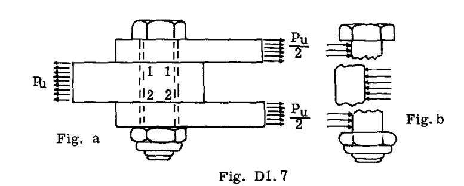

は、ボルトに作用する力または圧力、および応力が十分な場合に発生する可能性のある破損を示している。

$P_u$ をフィッティングに作用する最大荷重または終局荷重とする。この力 $P_u$ は、セクション (1-1) および (2-2) におけるボルトのせん断強度によって抵抗されなければならない。したがって、

$$P_{u(\text{bolt shear})} = F_{su} \cdot A \cdot 2
\qquad (1)$$

ここで、 * $F_{su}$ = ボルト材料の極限せん断応力 * $A$ = ボルトの断面積

### ボルトの曲げによる破損

ボルトの曲げに関する主な懸念は、制限荷重の下でボルトの曲げたわみが残留変形（永久変形）とならないようにすることである。このような変形が発生すると、ボルトの取り外しが困難になるからである。ボルトの曲げ応力については、後の記事で議論する。

### フィッティングのラグ部分の破損

フィッティングのラグ部分とは、オスとメスのフィッティングユニットを接続する単一のボルト用の穴を含むフィッティングの部分を指す。破損挙動に関する簡略化された仮定と、それに続く以下の方程式は、ラグ強度の迅速な概略チェックのために広く使用されてきた。これに続く手順を「Method 1」と呼ぶ。

### ボルト＆ラグ強度解析の Method 1

#### 引張による破損

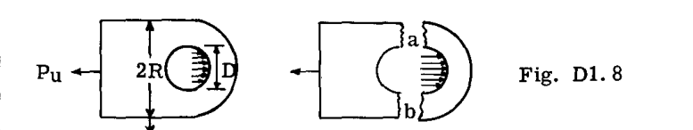

は、ボルト穴の中心線を通る断面上の引張応力によって、フィッティングプレートがどのように引き裂かれるかを示している。フィッティングのオス部分とメス部分の両方が、荷重を穴の中心線を越えて伝達しなければならないため、フィッティングの設計においては両方の部分を考慮しなければならない。許容荷重 $P_u$ を、

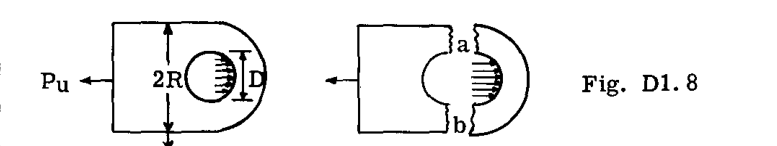

の点 (a) および (b) における極限抵抗引張応力と等置することにより、次式を得る。

$$P_{u(\text{tension})} = F_{tu} (2R - D) t
\qquad (2)$$

ここで、 * $F_{tu}$ = プレート材料の極限引張強度

式 (2) は、断面上の引張応力が均一であると仮定している。これは実際には正しくなく、穴の周囲の応力の流れが応力集中を引き起こす。この応力集中を考慮するために、25%の安全余裕（margin of safety）が必要である。

#### せん断引き裂き（Shear Tear Out）による破損

$$P_{u(\text{shear out})} = F_{su} A_s
\qquad (3)$$

ここで、 * $F_{su}$ = プレート材料の極限せん断強度 * $A_s$ = せん断引き裂き面積

#### プレート上のブッシングの支圧（Bearing）による破損

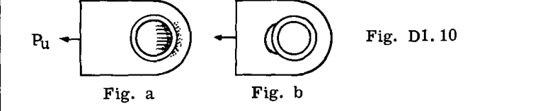

では、引張力 $P$ によってボルト（図示せず）がブッシング壁を押し、それがさらにプレート壁を押し付ける。もし圧力が十分に高ければ、穴に隣接するプレート材料が潰れて流れ始め、ボルトとブッシングが移動できるようになり、その結果、図 b に示すような長穴が生じる。荷重 $P_u$ を支圧面上の極限支圧強度と等置すると、次のように書くことができる。

$$P_u = F_{br} D t
\qquad (4)$$

ここで、 * $F_{br}$ = 許容支圧応力 * $D$ = ブッシングの直径 * $t$ = プレートの厚さ

50%の安全余裕を要求することが良好な実務とされる。

#### ボルトブッシングの支圧による破損

ブッシングはプレートの穴に圧入されるため、密着嵌合（タイトフィット）とみなされる。フィッティングボルトは通常、取り外し可能とみなされるため、ボルトを挿入および取り外しできるように、ボルトとブッシングの内径の間に特定の公差が必要である。もしフィッティングが反転荷重を受ける場合、フィッティングのわずかなガタがフィッティングに衝撃を与える傾向がある。また、フィッティングはボルト上でわずかな回転が発生するようなものである場合があり、これがボルトとブッシングの間の摩耗を引き起こす傾向がある。したがって、ブッシングの破損は、前述の「プレート上のブッシングの支圧」で説明したのと同様の方法で発生する可能性があるため、ボルトとブッシングの間の支圧圧力をチェックするのが一般的である。この場合、前と同様に、

$$P_u = F_{br} D t
\qquad (5)$$

ここで、 * $D$ = ボルトの直径

50%の安全余裕を維持すべきである。もしフィッティングが荷重下で稀に回転するが、衝撃や振動を伴わない荷重を受ける場合は、100%の安全余裕を要求する。もし稀な回転を伴う衝撃や振動が存在する場合は、150%の安全余裕を要求する。衝撃は、着陸装置、銃架、ホイスト、係留および牽引接続などの構造で発生するとみなされる。

### ラグの安全余裕に関する一般的コメント

一般に、機体の安全を確保する上での重要性に比べてラグの重量は小さいため、ラグを保守的（安全側）に設計することが優れた設計実務である。製造における不正確さは制御が困難である。元の設計でブッシングが使用されていない場合でも、ブッシング用の穴あけ加工ができるように十分な材料を確保しておくことが優れた設計実務である。鋳物をフィッティングとして使用する場合は、鋳物材料の延性が低いため、制限荷重に対してはるかに高い安全率が規定される。

## D1.11 Method 2. 軸方向荷重下のラグ強度解析

Cozzone、Melcon、および Hobbit（参考文献3および4）による包括的な研究と試験プログラムにより、Method 1 に示された手順はやや修正されている。重要な違いは、試験結果から導き出された曲線が、ネットセクション（正味断面）上の引張および Method 1 で仮定されたせん断引き裂き破損に対して使用する応力集中係数を提供し、これが複合せん断引き裂き-支圧破損（combined shear-out bearing failure）に置き換えられたことである。

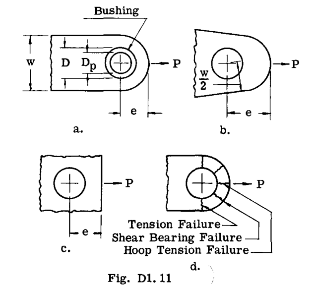

は、参考文献3から引用した、ラグとピンの組み合わせおよび破損のタイプを示している。

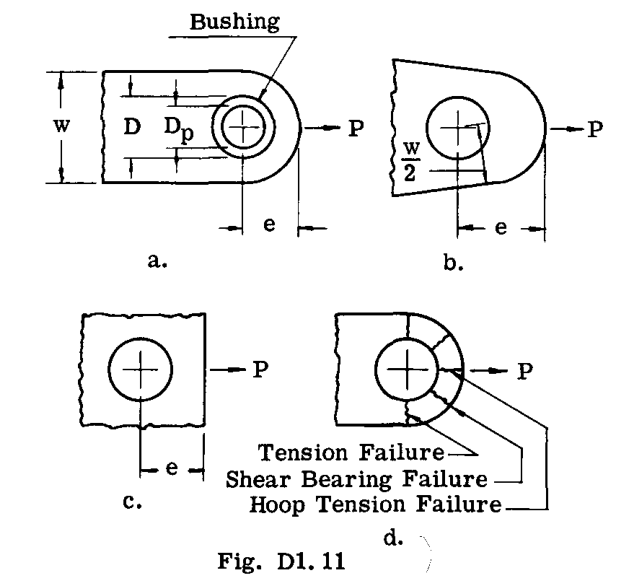

Fig. D1.11

破損の方法およびラグ強度解析の方法は以下の通りである。

### ネットセクション全体の引張（Tension Across the Net Section）

応力集中があるため、ネット断面上の応力を一様とみなすことはできない。ラグの極限許容引張荷重 $P_u$ は次式に等しい。

$$P_u = K_t F_{tu} A_t
\qquad (6)$$

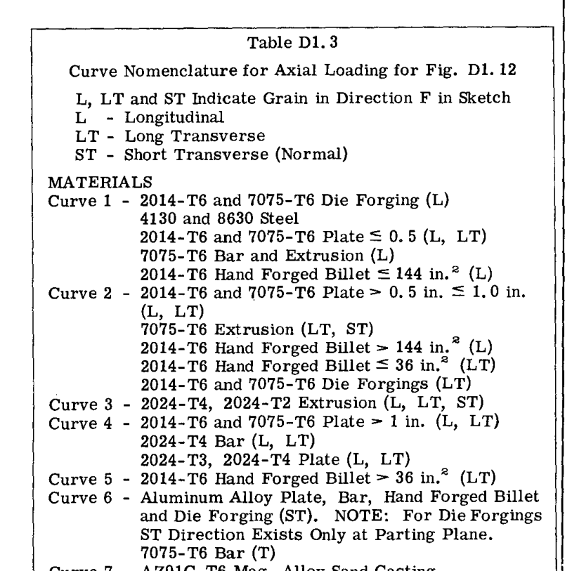

Table D1.3

### せん断引き裂き-支圧強度（Shear Out-Bearing Strength）

せん断引き裂きと支圧による破損は密接に関連しており、実験曲線に基づく単一の計算でカバーされる。このせん断引き裂き-支圧タイプの破損における極限または破壊荷重は以下の通りである。

$$P_{bru} = K_{bru} F_{tu} A_{br}
\qquad (7)$$

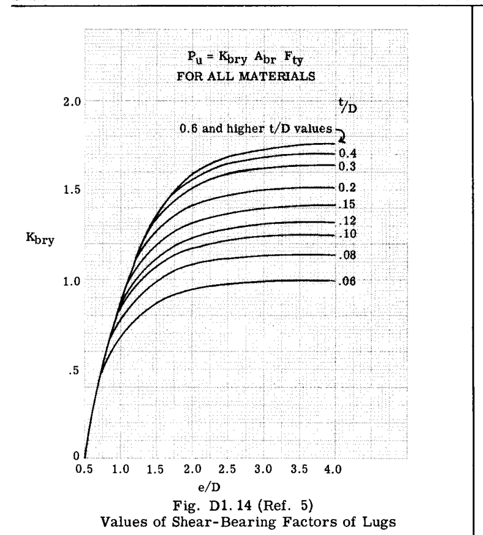

は $K_{bry}$ を求めるための曲線を示している。

### ブッシングの降伏（Bushing Yield）

$A_{br}$ は、ピン上のブッシングの支圧面積、またはラグ上のブッシングの支圧面積のうち、いずれか小さい方の値とする（後者は、ブッシングの外側チャンファーや油溝などの結果として小さくなることがある）。このとき、ブッシングの許容降伏支圧荷重は以下のようになる。

$$P_{bry} = 1.85 F_{cy} A_{br}
\qquad (9)$$

ここで、 $F_{cy}$ はブッシング材料の圧縮降伏強度である。

### ボルトまたはピンのせん断強度

ボルトのせん断強度は、Method 1 で示されたものと同様の方法で計算される。

### ボルトまたはピンの曲げ

ボルトの曲げ強度に関する事項は、Art. D1.14 で扱われる。

## D1.12 横方向荷重下のラグ強度解析

フィッティングユニットのラグが横方向の荷重のみを受ける場合が発生する。Melcon と Hobbit は（参考文献4）において、極限横方向または破壊荷重を単一の方程式で表している。

$$P_{tu} = K_{tu} A_{br} F_{tu}
\qquad (10)$$

同様に、ラグの降伏強度は、

$$P_{ty} = K_{ty} A_{br} F_{ty}
\qquad (11)$$

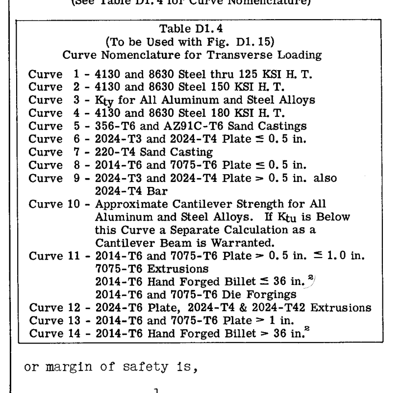

Table D1.4

## D1.13 斜め荷重（Oblique Loads）下のラグ強度解析

フィッティングのラグは、しばしば斜め荷重を受ける。参考文献4は、この荷重ケースに対して以下のアプローチを提供している。

作用荷重を軸方向成分と横方向成分に分解する。次に、以下の相互作用方程式を使用する。

$$R_a^{1.6} + R_{tr}^{1.6} = 1
\qquad (12)$$

または、安全余裕は、

$$M.S. = \frac{1}{(R_a^{1.6} + R_{tr}^{1.6})^{0.625}} - 1
\qquad (13)$$

ここで、 $R_a$ = 作用する極限荷重の軸方向成分を、式 (6) または (7) で得られた値のうち小さい方で除したもの。

$R_{tr}$ = 作用する極限荷重の横方向成分を、式 (10) における $P_{tu}$ の値で除したもの。

## D1.15 例題

### 問題 1

エンジンマウントのフィッティングが、直径 5/8 インチの AN スチール製ボルトによってナセルフィッティングに取り付けられている。ボルトに作用する極限荷重または設計荷重は、引張 = 5800 lbs.、せん断 = 16700 lbs. である。振動のため、25%の安全余裕が必要とされる。

#### 解答

これはボルトにおける引張とせん断の複合荷重の問題である。

このとき、

$$M.S. = \frac{P_{s(\text{allow})}}{x} - 1 = \frac{22400}{16700} - 1 =
0.34$$

または、

$$M.S. = \frac{P_{t(\text{allow})}}{y} - 1 = \frac{7700}{5800} - 1 = 0.34$$

規定された要求安全余裕は 0.25 であったため、ボルト強度は十分である。

### 問題 2

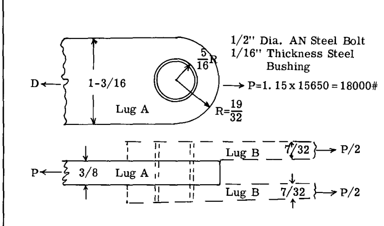

は、シングルピンフィッティングを示している。ラグの材料は AISI スチールで、熱処理により $F_{tu} = 125,000\text{ psi}$ である。ボルトは AN スチールで、 $F_{tu} = 125,000\text{ psi}$ である。ブッシングはスチール製で、 $F_{tu} = 125,000\text{ psi}$ である。フィッティングは 15650 lb. の極限引張荷重を受ける。フィッティングの強度は設計荷重に対してチェックされる。チェックは Method 1 と Method 2 の両方の方法で行われる。

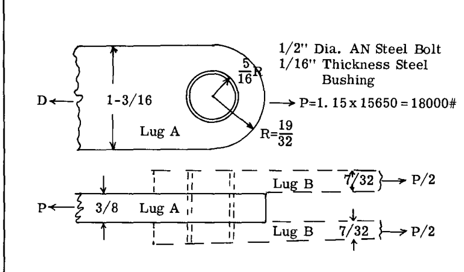

Fig. D1.17

#### METHOD 1 による解決

軍用航空機で標準的な実務である、1.15のフィッティング安全率を使用する。

$$\text{設計フィッティング荷重} = 1.15 \times 15650 = 18000\text{ lb.}$$

##### ボルトせん断強度のチェック

ボルトはダブルせん断（両面せん断）である。Table D1.1 から、直径 1/2 インチの AN スチール製ボルトの単一面せん断強度は 14700 lb. である。

したがって、

$$P_u = 2 \times 14700 = 29400\text{ lb.}$$

$$M.S. = \frac{29400}{18000} - 1 = 0.62$$

##### ボルトの曲げのチェック

$$b = 0.5t_1 + 0.25t_2 + g \quad (\text{g は } 1/64\text{ インチとする})$$

$$b = 0.5 (0.218) + 0.25 (0.375) + 0.0156 = 0.218\text{ インチ}$$

$$\text{ボルトの曲げモーメント} = 0.5 P b = 0.5 \times 18000 \times 0.218
= 1965\text{ in. lb.}$$

$$f_b = \frac{M r}{I} = \frac{1965 \times 0.25}{0.003069} = 160,000\text{
psi}$$

（ボルトの慣性モーメントについては Table D1.1 を参照）

Table D1.1 から、AN スチール製ボルトの $F_b$ は 180,000 である。

したがって、

$$M.S. = \frac{180,000}{160,000} - 1 = 0.12$$

##### ラグ A のチェック

ラグ B の厚さはラグ A の半分以上あるため、このラグ（ラグ A）の方がラグ B よりもクリティカルである。

##### ボルト穴を通る引張のチェック

$$P_u = F_{tu} A_t$$

$$P_u = 125,000 \times (1.1875 - 0.625) \times 0.375 = 26,400\text{ lb.}$$

$$M.S. = \frac{26,400}{18000} - 1 = 0.46$$

応力集中を考慮するため、Method 1 では 0.25 の安全余裕（M.S.）を維持することを求めているため、ラグの引張強度は問題ない。

##### ラグのせん断引き裂き強度のチェック

$$P_u = F_{su} A_s, \quad F_{su} = 82,000$$

$$P_u = 82,000 \times (0.5937 - 0.3125) \times 2 \times 0.375 =
17,300\text{ lb.}$$

##### 支圧強度（Bearing Strength）

ブッシングとラグは同じ極限強度（ $F_{tu}$ ）を持っているため、ブッシング上のボルトは支圧面積が小さいため、支圧がクリティカルになる。50%の追加の安全余裕が必要とされるか、または許容支圧応力 $F_{br}$ を1.5で除する必要がある。

$$P_u = \frac{194,000}{1.50} \times 0.50 \times 0.375 = 24,300\text{ lb.}$$

$$M.S. = \frac{24,300}{18,000} - 1 = 0.35$$

#### METHOD 2 による解決

ボルトのせん断強度およびボルトの曲げ強度は、Method 1 と同様に計算されるため、計算は繰り返さない。

##### 引張ネットセクション

$$P_u = K_t F_{tu} A_t$$

$$P_u = 0.98 \times 125,000 \times (1.1875 - 0.625) \times 0.375 =
25,800\text{ lb.}$$

$$M.S. = \frac{25,800}{18,000} - 1 = 0.43$$

##### せん断支圧強度（Shear Bearing Strength）

$$P_{bru} = K_{bru} F_{tu} A_{br}$$

$$\frac{D}{t} = \frac{0.625}{0.375} = 1.65$$

$$\frac{e}{D} = \frac{0.5937}{0.625} = 0.95$$

$$P_{bru} = 0.80 \times 125,000 \times 0.625 \times 0.375 = 23,400\text{
lb.}$$

$$M.S. = \frac{23,400}{18,000} - 1 = 0.30$$

読者は、Method 2 によるせん断引き裂き強度が Method 1 によるものよりもかなり大きいことに注目すべきである。

##### ブッシングの降伏

$$P_{bry} = 1.85 F_{cy} A_{br} \quad (F_{cy} = 113,000 \text{ (} F_{tu} =
125,000 \text{ のスチールの場合)})$$

$$P_{bry} = 1.85 \times 113,000 \times 0.500 \times 0.375 = 39,000\text{
lb.}$$

$$M.S. = \frac{39,000}{18,000} - 1 = 1.17$$

### 問題 3

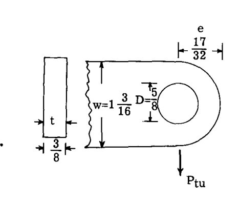

#### 解答

式 (10) から、破壊荷重は、

$$P_{tu} = K_{tu} A_{br} F_{tu}$$

$$A_{av} = \frac{6}{\frac{3}{A_1} + \frac{1}{A_2} + \frac{1}{A_3} +
\frac{1}{A_4}}$$

$$A_1 = A_4 = 0.14, \quad A_2 = A_3 = 0.105$$

これより、

$$A_{av} = \frac{6}{\frac{3}{0.14} + \frac{1}{0.105} + \frac{1}{0.105} +
\frac{1}{0.14}} = 0.126$$

$$A_{br} = 0.375 \times 0.625 = 0.234, \quad \frac{A_{av}}{A_{br}} =
\frac{0.126}{0.234} = 0.54$$

したがって、

$$P_{tu} = 0.74 \times 0.234 \times 125,000 = 21,600\text{ lb.}$$

### 問題 4

#### 解答

設計フィッティング荷重 = 引張 +33,000 lb. および圧縮 -25,000 lb. である。これらの荷重には、1.15のフィッティング安全率が含まれている。

$P_u$ を、さまざまな破損モードにおけるフィッティングユニットの極限強度とする。

##### ヒンジピンのせん断強度のチェック

ヒンジピンの直径は 5/8 であり、材料は AISI スチール、熱処理により $F_{tu} = 150,000$ である。 $F_{su} = 95,000$ である。ピンはダブルせん断（両面せん断）である。

$$P_u = F_{su} A_s = 95,000 \times 0.3068 \times 2 = 58,300\text{ lb.}$$

$$M.S. = \frac{58,300}{33,000} - 1 = 0.77$$

##### ヒンジピンの曲げ強度のチェック

$$b = 0.5t_1 + 0.25t_2 + g \quad (\text{隙間 g は } 1/64\text{
インチとする})$$

$$b = 0.5 \times 0.3125 + 0.25 \times 0.625 + 1/64 = 0.328\text{ in.}$$

$$\text{ピン曲げモーメント } M = 0.5 P b = 0.5 \times 33,000 \times 0.328
= 5,410\text{ in. lb.}$$

$$f_b = \frac{M r}{I} = \frac{5,410 \times 0.3125}{0.00749} =
226,000\text{ psi}$$

曲げにおける破断係数 $F_b$ は、Chapter C3 の方法によって計算される。

$$F_b = F_{tu} + f_0 (k - 1)$$

中実丸棒の場合、 $K = 1.7$ である（Chapter C3 の Fig. C3.7 を参照）。

$$M.S. = \frac{258,000}{226,000} - 1 = 0.14$$

##### ラグのせん断支圧引き裂きのチェック

$$P_{bru} = K_{bru} F_{tu} A_{br}$$

$$\frac{D}{t} = \frac{0.75}{0.625} = 1.2, \quad \frac{e}{D} =
\frac{0.6875}{0.75} = 0.92$$

$$M.S. = \frac{51,500}{33,000} - 1 = 0.56 \quad (\text{少なくとも 0.15
の余裕が望ましい})$$

##### ピン穴を通るラグ断面の引張強度のチェック

$$P_u = K_t F_{tu} A_t$$

$$\frac{W}{D} = \frac{1.125}{0.75} = 1.5$$

$$P_u = 0.99 \times 150,000 \times (1.125 - 0.75) \times 0.625 =
34,800\text{ lb.}$$

$$M.S. = \frac{34,800}{33,000} - 1 = 0.06$$

0.15の安全余裕（M.S.）を持つことが望ましい。

##### スチールフィッティングの断面 2-2 の引張強度のチェック

$$\text{ネット引張面積} = (1.125 - 0.3125) \times 0.375 = 0.305$$

保守的になるように、

$$P_u = 0.91 \times 150,000 \times 0.305 = 41,700\text{ lb.}$$

$$M.S. = \frac{41,700}{33,000} - 1 = 0.26$$

##### 断面 3-3 におけるスチールフィッティングの断面のチェック

$$P_u = 0.91 \times 150,000 \times 0.204 = 27,900\text{ lb.}$$

$$M.S. = \frac{27,900}{16,500} - 1 = 0.69$$

##### 4本の直径 5/16 ボルトのせん断強度のチェック

ボルトはダブルせん断（両面せん断）である。

$$P_u = 4 \times 2 \times 5,750 = 46,000\text{ lb.}$$

$$M.S. = \frac{46,000}{33,000} - 1 = 0.39$$

##### スチールフィッティングにおけるボルトの支圧のチェック

支圧面積が小さいため、断面 3-3 または 4-4 がクリティカルである。

150,000スチールの許容支圧応力は 218,000 である。

$$P_u = F_{br} A_{br} = 218,000 \times 0.3125 \times 0.25 = 17,000\text{
lb.}$$

$$M.S. = \frac{17,000}{8,250} - 1 = 1.06$$

##### 7075-T6 チャンネルにおけるボルトの支圧

7075アルミニウム合金に対する $F_{br} = 106,000$ である。

$$P_u = 106,000 \times 0.3125 \times 0.25 = 8,300\text{ lb.}$$

$$M.S. = \frac{8,300}{8,250} - 1 = 0.01$$

##### 断面 4-4 におけるチャンネルの引張強度のチェック

断面における荷重 = 33,000 である。

$$\text{ネット面積} = 0.70 - 0.25 \times 0.3125 = 0.622$$

7075材料に対する $F_{tu} = 78,000$ である。

$$P_u = 78,000 \times 0.622 = 48,500\text{ lb.}$$

$$M.S. = \frac{48,500}{33,000} - 1 = 0.47 \quad
(\text{これは応力集中を十分に考慮している})$$

##### ボルト B1 の背後にあるチャンネルのせん断引き裂きのチェック

$$\text{せん断引き裂き距離} = 0.625 - 0.156 = 0.469$$

$$\text{せん断引き裂き面積} = 2 \times 0.469 \times 0.25 = 0.234$$

$$P_u = F_{su} A_s = 43,000 \times 0.234 = 10,100\text{ lb.}$$

$$M.S. = \frac{10,100}{8,250} - 1 = 0.23 \quad (\text{Method 1
による保守的な計算})$$

##### ボルト B4 の背後にあるスチールフィッティングのせん断引き裂き

$$F_{su} = 95,000$$

$$\text{せん断引き裂き面積 } A_s = (0.4375 - 0.1565) \times 2 \times 0.25
= 0.141$$

$$P_u = 0.141 \times 95,000 = 13,400$$

$$M.S. = \frac{13,400}{8,250} - 1 = 0.62$$

##### ブッシングの降伏強度

$$P_{bry} = 1.85 F_{cy} A_{br}, \quad F_{cy} = 113,000 \text{
(125,000スチールの剪断の場合)}$$

$$P_{bry} = 1.85 \times 113,000 \times 0.625 \times 0.625 = 81,700\text{
lb.}$$

荷重 = 33,000 であり、クリティカルではない。

## D1.16 複数ボルトフィッティングのボルト荷重：異なるボルトサイズ、同心荷重

複数ボルトフィッティングを設計または強度チェックする際、全フィッティング荷重のどの割合を各ボルトが伝達するのかという疑問が生じる。この分布は、穴におけるボルトの嵌合やボルトの締め付け状態、ボルト穴の支圧変形や伸び、ボルトやピンのせん断変形、接続されるフィッティング部材や部材の引張または圧縮軸変形、およびその他の多くの軽微な影響など、多くの事柄によって影響を受ける可能性がある。

航空機材料はかなりの延性を持っているため、フィッティングが適切に設計されていれば、フィッティングにかかる荷重が最大値に近づくにつれて、ボルトにかかる荷重はボルトのせん断強度に比例する傾向がある。すなわち、ボルトの複合せん断強度が臨界強度（限界強度）である場合、支圧、せん断、および引張におけるフィッティング材料の降伏は、ボルトの荷重をそれらのせん断強度に比例して均等化する傾向がある。フィッティングプレートの弾性限度を下回る応力に対しては、ボルト荷重分布は、各ボルトの支圧面積に密接に比例することは疑いない。一次的な関心は破壊強度にあるため、通常はボルトのせん断強度に比例したボルト荷重分布が仮定される。

ここで、 * $P$ = フィッティングの設計荷重 * $P_s$ = 任意のボルトの許容せん断強度 * $P_n$ = ボルト $n$ にかかる荷重 * $P_{sn}$ = ボルト $n$ の許容せん断強度

したがって、次のように書くことができる。

$$P_n = P \frac{P_{sn}}{\sum P_s}
\qquad (A)$$

### ボルト荷重分布の例題

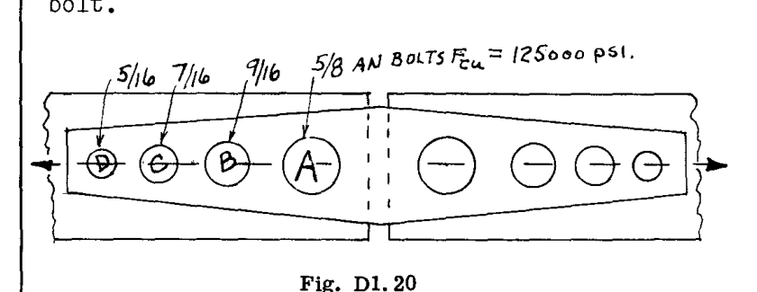

は、100,000 lbs. の同心荷重を受ける複数ボルトフィッティングユニットを示している。各ボルトによって伝達される荷重を求めよ。

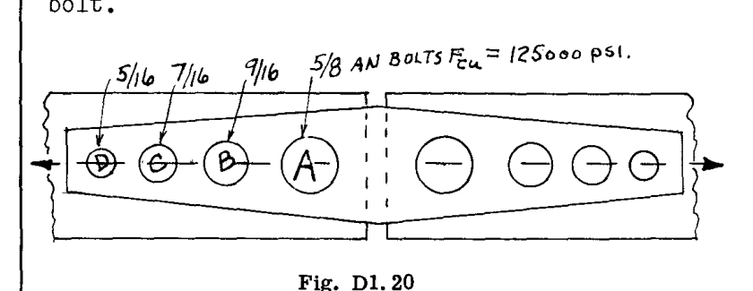

Fig. D1.20

各ボルトへの荷重の分布は以下の通りである。

$$P_a = P \left( \frac{P_{sa}}{\sum P_s} \right) = 100,000 \times
\frac{46,020}{117,340} = 39,200\text{ lb.}$$

$$P_b = 100,000 \times \frac{37,274}{117,340} = 31,800\text{ lb.}$$

$$P_c = 100,000 \times \frac{22,544}{117,340} = 19,200\text{ lb.}$$

$$P_d = 100,000 \times \frac{11,502}{117,340} = 9,800\text{ lb.}$$

4本のボルトにかかる全荷重を合計すると、100,000 lb. になる。

## D1.17 偏心荷重を受ける複数リベットまたはボルト継手

ボルト群の抵抗の図心（重心）は、ボルト面積の図心に対応する。

$$P_V = -200\text{ lb.}, \quad P_H = 1000\text{ lb.}$$

および、

$$M_O = -200 \times 1.75 - 1000 \times 0.25 = -600\text{ in. lb.}$$

$P_V$ および $P_H$ はボルト群の図心を通って作用するため、各ボルトによって均等に反力を生じる。したがって、 $P_V$ による各ボルトの $V$ 荷重 = $-200 / 4 = -50\text{ lb.}$ 、および $P_H$ による各ボルトの $H$ 荷重 = $1000 / 4 = 250\text{ lb.}$ である。

モーメント荷重 $M_O = -600\text{ in. lb.}$ によって各ボルトに生じる荷重は、ボルト群の図心からのボルトの距離に直接比例して変化する。

$r_a$ を、ボルト群の図心からボルト (a) への距離とする。このとき、ボルト (a) によって生じる抵抗モーメントは $F_a r_a$ に等しく、ここで $F_a$ はボルト (a) にかかる荷重に等しい。ボルト荷重はそれらの図心からの距離に比例するため、ボルト (b) によって生じる抵抗モーメント $M_b$ は以下のようになる。

$$\left( F_a \frac{r_b}{r_a} \right) r_b \quad \text{または} \quad F_a
\frac{r_b^2}{r_a}$$

そして、同様にボルト (c) に対しても、

$$M_c = F_a \frac{r_c^2}{r_a}$$

およびボルト (d) に対しても、

$$M_d = F_a \frac{r_d^2}{r_a}$$

したがって、ボルト群の全モーメント抵抗は以下に等しい。

$$M = \frac{F_a r_a^2 + F_a r_b^2 + F_a r_c^2 + F_a r_d^2}{r_a}
\qquad (14)$$

これより、

$$F_a = \frac{M r_a}{r_a^2 + r_b^2 + r_c^2 + r_d^2} = \frac{M r_a}{I}
\qquad (15)$$

ここで、 $I = \sum r^2$ （ボルト群の断面二次極モーメント）である。

したがって、他のボルトにおける荷重については、

$$F_b = \frac{M r_b}{I}, \quad F_c = \frac{M r_c}{I}, \quad F_d = \frac{M
r_d}{I}$$

$$r_a = r_b = r_c = r_d = 1.25"$$

したがって、

$$I = \sum r^2 = 4 \times 1.25^2 = 6.25\text{ in.}$$

したがって、各ボルトにかかるモーメント荷重 $F_m$ は以下のようになる。

$$F_m = \frac{M r}{I} = \frac{-600 \times 1.25}{6.25} = 120\text{ lb.}$$

$$\sum H = 250 + 120 \times \frac{1}{1.25} + 0 = 346\text{ lb.}$$

$$\sum V = -50 - 120 \times \frac{0.75}{1.25} + 0 = -122\text{ lb.}$$

したがって、

$$R = \sqrt{\sum H^2 + \sum V^2} = \sqrt{346^2 + 122^2} = 367\text{ lb.}$$

### ボルトまたはリベットの直径が異なる場合

接合ボルトまたはリベットがすべて同じサイズではない場合、各ボルトにかかるモーメント荷重は、ボルト面積にボルト群の図心までの距離を乗じたものに比例する。したがって、ボルト面積が式 (15) に入らなければならない。

したがって、

$$F_a = \frac{M A_a r_a}{n_a A_a r_a^2 + n_b A_b r_b^2 + n_c A_c r_c^2 +
n_d A_d r_d^2}
\qquad (16)$$

ここで、 $n$ = 各サイズのボルトの数である。

複数ボルト群における荷重の理論は近似にすぎないため、妥当な安全余裕を維持すべきである。

## 1.18 リベット接続：リベットの種類

航空宇宙構造の観点から、リベットは大きく2つの一般的な分類に分けることができる。

1. 突出頭（Protruding Head）タイプのリベット
2. 皿頭（Flush）タイプのリベット

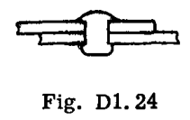

は突出頭タイプのリベットを示している。

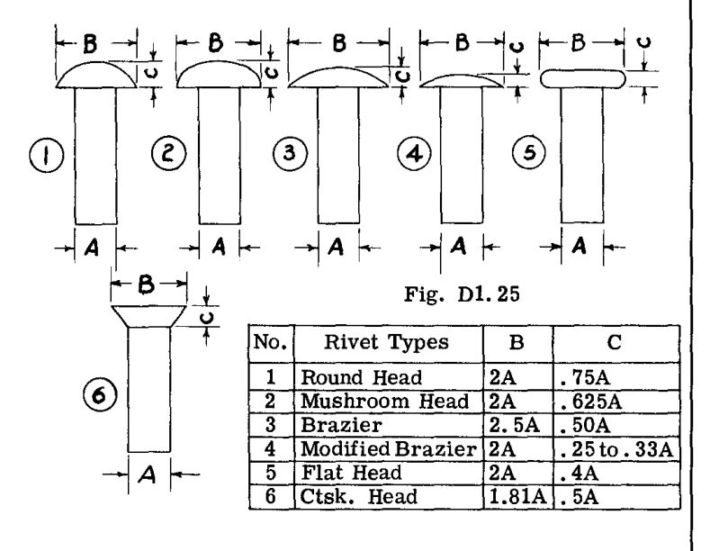

は、過去に使用されてきた突出頭タイプのリベットのいくつかの変形を示している。

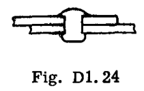

Fig. D1.24

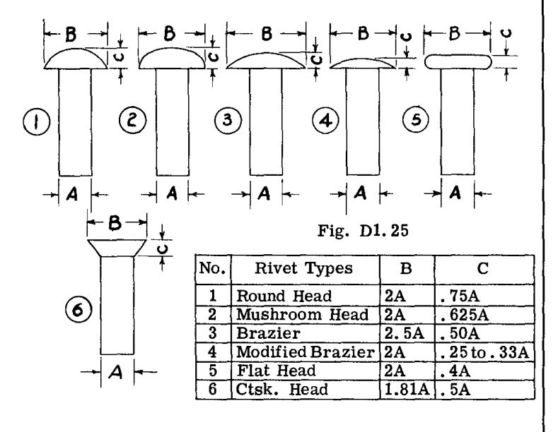

Fig. D1.25

長年にわたり、丸頭（Round Head）リベットがすべての内部作業に使用され、高速時代の前には表面リベットとしても使用されていた。風洞実験によってこのようなリベットが少なからぬ抗力（ドラッグ）を発生させることが示されると、設計者は頭部の突出がより少ないリベットに移行し、ブラジャー（Brazier）型および修正ブラジャー型の呼び名の頭部が開発された。その後、比較的高い飛行速度の時代が到来すると、特に航空機表面の特定の敏感な部分において平滑な表面（フラッシュサーフェス）が必要となり、その結果、シートのプレス皿もみや機械皿もみを伴う、皿頭リベットの様々な変形が開発された。

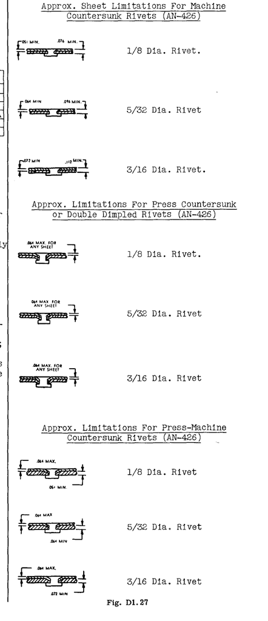

は、皿頭リベットの3つの方法に対する、おおよそのシート厚さの限界を示している。

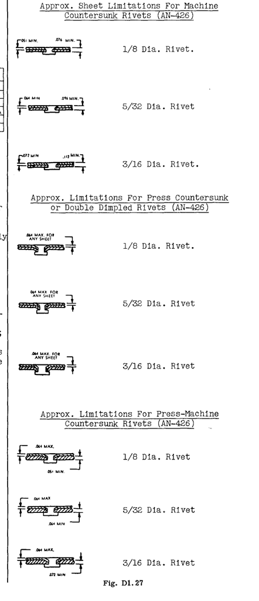

Fig. D1.27